**Project Structure/**

├── Objective  
├── About Dataset & Data-cleaning  
├── Approach  
├── Descriptive Analysis  
├── Exploratory Data Analysis  
├── Table Joins  
└── Modeling : Encoding - Correlation - Nested Machine Learning Models - Cross Validation - Feature Importance

# REAL IMPACT OF DWELL TIMES BETWEEN CASH, TOTO, MOBILE APP AND KEYCARD – B&H BUSES

# Objective

This project examines how dwell times affect the Route 7 bus service between George Street, Hove, and Brighton Marina in Brighton,UK. Key goals are to understand how different payment methods and ticket types impact dwell times (the time a vehicle spends at a scheduled stop without moving), identify what helps passengers board more efficiently,finding hidden trends and explore ways to improve bus operations.

```python
import numpy as np
import pandas as pd
import statsmodels.api as sm
from sklearn.preprocessing import LabelEncoder
import missingno as msno # for missing values
import matplotlib.pyplot as plt
import seaborn as sns
sns.set_style('darkgrid')
```

# About Dataset & Data-cleaning

This project analyzes Route 7 bus operations using three datasets: ticketData from E.P. Morris, Route_7_Concessionary_data_ticketer from the Ticketer system, and Route_7_GPS_data. The data covers June 4th to June 10th, 2023, and includes ticket sales, passenger counts, ticket types, payment methods, passenger demographics, dwell times, punctuality, and other operational details.

In the initial analysis, we’ll explore ticket types from ticketData (E.P. Morris), which closely aligns with Ticketer data. We’ll also use GPS data to get insights into route patterns. For the next phase, we’ll merge Ticketer data and ticketData with GPS data for modeling, connecting them through the common "Bus number" field shared between Ticketer and GPS data.data.

### Route_7_Concessionary_data_ticketer

```python
Concess= pd.read_excel('Route_7_Concessionary_data_Ticketer.xlsx','Concessionary_Data')
Concess.head()
```

|  | Journey number | Route number | Operator | Date | Number | Ticket Time | Ticket Class | Fare Paid | Value of Ride | Origin Stage | Destination Stage | Driver number | Bus number | Duty number | Shadow | Custom Formula |
| --- | --- | --- | --- | --- | --- | --- | --- | --- | --- | --- | --- | --- | --- | --- | --- | --- |
| 0 | 259 | 7 | 0 | 2023-06-04 | 1 | 00:00:00 | Adult TOTO | 0.0 | 0 | 251 | 273.0 | 7325 | 487 | 2708 | 2.0 | NaN |
| 1 | 262 | 7 | 0 | 2023-06-04 | 1 | 00:01:01 | BH Ovr60 ENCTS | 0.0 | 0 | 251 | NaN | 6273 | 351 | 2714 | 0.0 | NaN |
| 2 | 262 | 7 | 0 | 2023-06-04 | 1 | 00:01:05 | Adult TOTO | 0.0 | 0 | 251 | 203.0 | 6273 | 351 | 2714 | 2.0 | NaN |
| 3 | 262 | 7 | 0 | 2023-06-04 | 1 | 00:01:12 | Adult TOTO | 0.0 | 0 | 251 | 203.0 | 6273 | 351 | 2714 | 2.0 | NaN |
| 4 | 264 | 7 | 0 | 2023-06-04 | 1 | 00:01:16 | M_Adult NtwkSvr | 0.0 | 0 | 132 | NaN | 7151 | 829 | 2730 | 0.0 | NaN |

```python
# renaming columns
Concess = Concess.rename(columns={'Ticket Time': 'Transaction Time', 'Ticket Class': 'Ticket Sub-Class','Journey number': 'Trip Number',
                                 'Destination Stage':'Destination Stop','Origin Stage':'Origin Stop'})
```

```python
Concess.drop_duplicates(inplace=True)
```

**Operator** & **Value of Ride**: Not needed, as it has a value of 0's only. **Number**: Not needed, as it has no meaningful values (1). **Driver Number**: Irrelevant, so it can be excluded. **Route Number**: Not required since the analysis focuses solely on Route 7.

```python
Concess = Concess.drop(['Operator', 'Route number','Value of Ride','Driver number', 'Number'], axis=1)  # dropping redundant columns
```

```python
null_columns = Concess.columns[Concess.isnull().any()].tolist()
print("Columns with NULL values:", null_columns)
```

```
Columns with NULL values: ['Destination Stop', 'Custom Formula']
```

```python
Concess['Custom Formula'].isnull().sum() # All values being null
```

```
75767
```

```python
Concess=Concess.drop('Custom Formula',axis=1) # dropping 'Custom Formula' column
```

```python
Concess['Destination Stop'].isnull().sum()
```

```
46634
```

```python
# Get all unique values and their frequencies
unique_values_frequencies = Concess['Destination Stop'].value_counts()

# Print each unique value with its frequency
print("Unique values and their frequencies in 'Destination Stop' before:")
for value, frequency in unique_values_frequencies.items():
    print(f"{value}: {frequency}")

# Get the frequency distribution of the unique values (normalized to probabilities)
unique_values_frequencies = Concess['Destination Stop'].value_counts(normalize=True)

# Create a function to apply proportional imputation
def proportional_impute(row, unique_values_frequencies):
    if pd.isnull(row):
        return np.random.choice(unique_values_frequencies.index, p=unique_values_frequencies.values)
    else:
        return row

# Apply the function to the 'Destination Stage' column
Concess['Destination Stop'] = Concess['Destination Stop'].apply(proportional_impute, unique_values_frequencies=unique_values_frequencies)

Concess['Destination Stop'] = Concess['Destination Stop'].astype(int) # float to int

# Get all unique values and their frequencies
unique_values_frequencies = Concess['Destination Stop'].value_counts()

# Print each unique value with its frequency
print("Unique values and their frequencies in 'Destination Stop' after:")
for value, frequency in unique_values_frequencies.items():
    print(f"{value}: {frequency}")
```

```
Unique values and their frequencies in 'Destination Stop' before:
222.0: 5423
38.0: 3563
273.0: 3483
132.0: 3358
203.0: 3111
251.0: 2925
319.0: 2039
129.0: 1979
73.0: 1905
232.0: 1347
Unique values and their frequencies in 'Destination Stop' after:
222: 14133
38: 9333
273: 8956
132: 8699
203: 8033
251: 7648
319: 5398
129: 5085
73: 4997
232: 3485
```

```python
Concess['Ticket Sub-Class'].unique()
```

```
array(['Adult TOTO', 'BH Ovr60 ENCTS', 'M_Adult NtwkSvr',
       'M_Adult CitySvr', 'Adult NtwkSaver', 'BH Disab ENCTS',
       'M_Stu CitySaver', 'M_Child CitySvr', 'Adult Single',
       'Adult City Saver', 'M_Stu NtwkSaver', 'Child Single',
       'Adult citySAVER', 'Staff Pass BH', 'Adult CitySvr', 'Pass',
       'BH/ES Ch Sgl Acc', 'M_Special £2 Sgl', 'Disabled ENCTS',
       'Over60 ENCTS', 'BusID City Saver', 'Stu CitySaver',
       'Stu NetworkSaver', 'M_Child NtwkSvr', 'M_Adult MVoyager',
       'NHS Commuter', 'Adult NetworkSvr', 'WS Disab ENCTS',
       'BusID NtwkSaver', 'Southern KeyGo', 'M_Duo CitySaver',
       'BusID Multitrip', 'M_Duo NetworkSvr', 'M_Child 50p Sgl',
       'Staff Pass MB', 'Excess £1', 'Excess 10p', 'Excess 50p',
       'NHS Inter-site', 'Child citySAVER', 'Family NwkSaver',
       'Child CitySvr', 'M_Family NtwkSvr', 'Family NetworkSv',
       'Concession Sgl', 'Stu MVoyager', 'M Ticket', 'Child Unpaid',
       'Adult Multitrip', 'Staff Pass GA', 'M_Family MVoyagr',
       'Ad CSS+NtwkSvr', 'Adult MVoyager', 'M_Ad Centrefare',
       'Child NwkSvr Wk', 'M_Child £1 Sgl', 'Child NetworkSvr',
       'Adult NetwkSaver', 'Excess 5p', 'Con/Stu CSS+NwkS',
       'M_Adult Quattro', 'Adult MVoyagr'], dtype=object)
```

```python
replacements = {
    'BH Disab ENCTS':'BH Disable ENCTS',
    'Adult CitySvr':'Adult citySAVER',
    'BH/ES Ch Sgl Acc':'BH/ES Ch Sgl Accom',
    'M_Special £2 Sgl':'Mobile Special £2 Single',
    'BusID City Saver':'BusID citySAVER',
    'Adult NetworkSvr':'Adult networkSAVER',
    'M_Family NtwkSvr':'Mobile Family networkSAVER',
    'Family NetworkSv':'Family networkSAVER',
    'Stu MVoyager':'Student Metrovoyager',
    'M_Adult CitySvr':'Mobile Adult citySAVER',
    'M_Adult NtwkSvr':'Mobile Adult networkSAVER',
    'Adult City Saver':'Adult citySAVER',
    'BusID City Saver':'BusID citySAVER',
    'M_Stu CitySaver':'Mobile Student citySAVER',
    'Stu CitySaver':'Student citySAVER',
    'Adult NtwkSaver':'Adult networkSAVER',
    'Adult CitySaver':'Adult citySAVER',
    'Stu NetworkSaver':'Student networkSAVER',
    'M_Child CitySvr':'Mobile Child citySAVER',
    'M_Child NtwkSvr':'Mobile Child networkSAVER',
    'M_Stu NtwkSaver':'Mobile Student networkSAVER',
    'BusID NtwkSaver':'BusID networkSAVER',
    'Adult CitySvr':'Adult citySAVER',
    'M_Duo CitySaver':'Mobile Duo citySAVER',
    'M_Duo NetworkSvr':'Mobile Duo networkSAVER',
    'M_Adult MVoyager':'Mobile Adult Metrovoyager',
    'Child CitySaver':'Child citySAVER',
    'Adult NetworkSvr':'Adult networkSAVER',
    'Child CitySvr':'Child citySAVER',
    'WS Disab ENCTS':'WS Disable ENCTS',
    'M_Family NtwkSvr':'Mobile Family networkSAVER',
    'M_Child 50p Sgl':'Mobile Child 50p Single',
    'Family NetworkSv':'Family networkSAVER',
    'Family NwkSaver':'Family networkSAVER',
    'M_Family MVoyagr':'Mobile Family Metrovoyager',
    'Child NetworkSvr':'Child networkSAVER',
    'Adult NetwkSaver':'Adult networkSAVER',
    'Stu MVoyager':'Student Metrovoyager',
    'M_Adult Quattro':'Mobile Adult Quattro',
    'Adult MVoyagr':'Adult Metrovoyager',
    'Adult MVoyager':'Adult Metrovoyager',
    'M_Child £1 Single':'Mobile Child £1 Single',
    'Concession Sgl':'Concession Single',
    'Child NwkSaver':'Child networkSAVER',
    'M Ticket':'Mobile Ticket',
    'M_Ad Centrefare':'Mobile Adult Centrefare',
    'Child NwkSvr Wk':'Child networkSAVER Week',
    'M_Child £1 Sgl':'Mobile Child £1 Single'

}
Concess['Ticket Sub-Class'] = Concess['Ticket Sub-Class'].replace(replacements)
```

### ticketData from E.P. Morris

```python
ticketer = pd.read_csv('ticketData.csv',encoding='Latin1') #reading the files
ticketer.head()
```

|  | ETM Route Code | Bus Stop Name | Op Date | Transaction Time | Ticket Class Description | Trip Number | Ticket Description | Net | Tickets | Pass | Conc | Passengers |
| --- | --- | --- | --- | --- | --- | --- | --- | --- | --- | --- | --- | --- |
| 0 | 7 | Arundel Road | 04/06/2023 | 05:23:30 | Autoscan | 1 | Adult TOTO | 0.0 | 1 | 0 | 0 | 1 |
| 1 | 7 | Arundel Road | 04/06/2023 | 05:23:34 | Autoscan | 1 | Adult TOTO | 0.0 | 1 | 0 | 0 | 1 |
| 2 | 7 | Arundel Road | 04/06/2023 | 05:23:36 | QR | 1 | M_Adult CitySvr | 0.0 | 0 | 1 | 0 | 1 |
| 3 | 7 | Arundel Road | 04/06/2023 | 05:25:00 | Smart | 1 | BH Ovr60 ENCTS | 0.0 | 0 | 0 | 1 | 1 |
| 4 | 7 | Arundel Road | 04/06/2023 | 05:25:06 | Autoscan | 1 | Adult TOTO | 0.0 | 1 | 0 | 0 | 1 |

```python
 # renaming the columns
ticketer = ticketer.rename(columns={'Op Date': 'Date', 'Bus Stop Name': 'Bus Stop','Ticket Class Description':'Ticket Class',
                                   'Ticket Description':'Ticket Sub-Class'})
ticketer['Date'] = pd.to_datetime(ticketer['Date'], format='%d/%m/%Y') # Convert the column to datetime objects
ticketer['Date'] = ticketer['Date'].dt.strftime('%Y-%m-%d') # Format datetime objects with day and month swapped
```

```python
ticketer.drop_duplicates(inplace=True) # Dropping duplicates
```

```python
ticketer = ticketer.drop('ETM Route Code', axis=1) # Dropping redundant values
```

```python
null_columns = ticketer.columns[ticketer.isnull().any()].tolist()
print("Columns with NULL values:", null_columns)
```

```
Columns with NULL values: []
```

```python
ticketer['Bus Stop'].unique()
```

```
array(['Arundel Road', 'Boundary Road (stop B)', 'Brighton Marina',
       'Brighton Station (stop A)', 'Brighton Station (stop E)',
       'Chesham Street', 'Clock Tower (stop L)', 'Clock Tower (stop N)',
       'College Place', 'Compton Avenue', 'County Hospital',
       'Devonshire Place', 'Eaton Gardens', 'George Street (stop J)',
       'Holland Road', 'Hove Station', 'Law Courts', 'LiDL Superstore',
       'Livingstone Road', 'Lyon Close', 'Marina Cinema',
       'Montefiore Road', 'North Road', 'North Street (stop C)',
       'North Street (stop X)', 'Old Steine (stop U)', 'Osmond Road',
       'Park Street', 'Rock Gardens', 'Roedean Road', 'Seven Dials',
       "St James's Street (stop J)", 'St Marys Hall', 'Sussex Square',
       'The Waterfront', 'Upper Bedford Street', 'Wilbury Villas'],
      dtype=object)
```

```python
# Modify values in 'Bus Stop' column to keep uniformity with 'GPS' table column
ticketer['Bus Stop'] = ticketer['Bus Stop'].replace("St James's Street (stop J)","St James's Street" )
```

```python
ticketer[['Net', 'Tickets', 'Passengers']].describe()
```

|  | Net | Tickets | Passengers |
| --- | --- | --- | --- |
| count | 76009.000000 | 76009.000000 | 76009.000000 |
| mean | 0.199891 | 0.402426 | 1.026694 |
| std | 0.888686 | 0.550958 | 0.318137 |
| min | -36.000000 | -9.000000 | -9.000000 |
| 25% | 0.000000 | 0.000000 | 1.000000 |
| 50% | 0.000000 | 0.000000 | 1.000000 |
| 75% | 0.000000 | 1.000000 | 1.000000 |
| max | 36.000000 | 15.000000 | 33.000000 |

```python
# Turning negative values into positive.
ticketer[['Net', 'Tickets', 'Passengers']] = ticketer[['Net', 'Tickets', 'Passengers']].abs()
```

```python
ticketer['Ticket Sub-Class'].unique()
```

```
array(['Adult TOTO', 'M_Adult CitySvr', 'BH Ovr60 ENCTS', 'Adult Single',
       'Adult City Saver', 'BH Disab ENCTS', 'M_Special £2 Sgl',
       'Over60 ENCTS', 'M_Adult NtwkSvr', 'BusID City Saver',
       'M_Stu CitySaver', 'Stu CitySaver', 'Staff Pass BH',
       'Adult NtwkSaver', 'Adult CitySaver', 'Credit', 'Stu NetworkSaver',
       'M_Child CitySvr', 'M_Child NtwkSvr', 'M_Stu NtwkSaver',
       'BH/ES Ch Sgl Accom', 'BusID NtwkSaver', 'Child Single',
       'Adult CitySvr', 'M_Duo CitySaver', 'M_Duo NetworkSvr',
       'NHS Inter-site', 'Southern KeyGo', 'M_Adult MVoyager',
       'Child CitySaver', 'Pass', 'BusID Multitrip', 'Adult NetworkSvr',
       'Disabled ENCTS', 'Child CitySvr', 'WS Disab ENCTS',
       'M_Family NtwkSvr', 'Child Unpaid', 'M_Child 50p Sgl',
       'Staff Pass MB', 'Family NetworkSv', 'Family NwkSaver',
       'Ad CSS+NtwkSvr', 'M_Family MVoyagr', 'Adult Multitrip',
       'Child NetworkSvr', 'Adult NetwkSaver', 'Con/Stu CSS+NwkS',
       'Stu MVoyager', 'M_Adult Quattro', 'Adult MVoyagr',
       'Adult MVoyager', 'M_Child £1 Single', 'Concession Sgl',
       'Child NwkSaver', 'M Ticket', 'NHS Commuter', 'M_Ad Centrefare',
       'Punch', 'Excess £1', 'Excess 10p', 'Excess 50p',
       'Child NwkSvr Wk', 'Excess 5p', 'Staff Pass GA'], dtype=object)
```

```python
replacements = {
    'M_Adult CitySvr':'Mobile Adult citySAVER',
    'M_Adult NtwkSvr':'Mobile Adult networkSAVER',
    'Adult City Saver':'Adult citySAVER',
    'BusID City Saver':'BusID citySAVER',
    'M_Stu CitySaver':'Mobile Student citySAVER',
    'Stu CitySaver':'Student citySAVER',
    'Adult NtwkSaver':'Adult networkSAVER',
    'Adult CitySaver':'Adult citySAVER',
    'Stu NetworkSaver':'Student networkSAVER',
    'M_Child CitySvr':'Mobile Child citySAVER',
    'M_Child NtwkSvr':'Mobile Child networkSAVER',
    'M_Stu NtwkSaver':'Mobile Student networkSAVER',
    'BusID NtwkSaver':'BusID networkSAVER',
    'Adult CitySvr':'Adult citySAVER',
    'M_Duo CitySaver':'Mobile Duo citySAVER',
    'M_Duo NetworkSvr':'Mobile Duo networkSAVER',
    'M_Adult MVoyager':'Mobile Adult Metrovoyager',
    'Child CitySaver':'Child citySAVER',
    'Adult NetworkSvr':'Adult networkSAVER',
    'Child CitySvr':'Child citySAVER',
    'WS Disab ENCTS':'WS Disable ENCTS',
    'M_Family NtwkSvr':'Mobile Family networkSAVER',
    'M_Child 50p Sgl':'Mobile Child 50p Single',
    'Family NetworkSv':'Family networkSAVER',
    'Family NwkSaver':'Family networkSAVER',
    'M_Family MVoyagr':'Mobile Family Metrovoyager',
    'Child NetworkSvr':'Child networkSAVER',
    'Adult NetwkSaver':'Adult networkSAVER',
    'Stu MVoyager':'Student Metrovoyager',
    'M_Adult Quattro':'Mobile Adult Quattro',
    'Adult MVoyagr':'Adult Metrovoyager',
    'Adult MVoyager':'Adult Metrovoyager',
    'M_Child £1 Single':'Mobile Child £1 Single',
    'Concession Sgl':'Concession Single',
    'Child NwkSaver':'Child networkSAVER',
    'M Ticket':'Mobile Ticket',
    'M_Ad Centrefare':'Mobile Adult Centrefare',
    'Child NwkSvr Wk':'Child networkSAVER Week' ,
    'M_Special £2 Sgl':'Mobile Special £2 Single',
    'BH Disab ENCTS':'BH Disable ENCTS',
    'Mobile_Child £1 Single':'Mobile Child £1 Single'
}

ticketer['Ticket Sub-Class'] = ticketer['Ticket Sub-Class'].replace(replacements)
```

### Route_7_GPS_data

```python
GPS = pd.read_excel('Route_7_GPS_Data.xlsx')
GPS.head()
```

|  | Block_No | Route_No | Route_Desc | Pattern_No | Direction | Unnamed: 5 | Rec Vehicle No | Location No | Unnamed: 8 | Date | Planned Arrival Time | Planned Departure Time | Actual Arrival Time | Actual Departure Time |
| --- | --- | --- | --- | --- | --- | --- | --- | --- | --- | --- | --- | --- | --- | --- |
| 0 | 501 | 7 | 7 | 1 | 1 | Timing Point | 322 | 756(0) | Brighton Marina | 2023-06-04 | 05:20:00 | 05:20:00 | 05:20:05 | 05:20:05 |
| 1 | 501 | 7 | 7 | 1 | 1 | Timing Point | 322 | 428(0) | Arundel Road Btn | 2023-06-04 | 05:22:00 | 05:22:00 | 05:22:11 | 05:22:40 |
| 2 | 501 | 7 | 7 | 1 | 1 | NonTiming Point | 322 | 427(1) | Lidl Superstore | 2023-06-04 | 05:22:23 | 05:22:23 | 05:22:56 | 05:23:01 |
| 3 | 501 | 7 | 7 | 1 | 1 | NonTiming Point | 322 | 437(0) | Sussex Square | 2023-06-04 | 05:23:04 | 05:23:04 | 05:23:19 | 05:23:51 |
| 4 | 501 | 7 | 7 | 1 | 1 | NonTiming Point | 322 | 426(1) | St Marys Hall | 2023-06-04 | 05:23:48 | 05:23:48 | 05:24:11 | 05:24:15 |

```python
GPS = GPS.rename(columns={'Rec Vehicle No': 'Bus number','Unnamed: 5': 'Timing Point', 'Unnamed: 8': 'Bus Stop'}) # renaming columns
```

```python
GPS.drop_duplicates(inplace=True)
```

```python
GPS = GPS.drop(['Route_No', 'Route_Desc','Pattern_No'], axis=1) # Dropping redundant values
```

```python
GPS['Bus Stop'].unique()
```

```
array(['Brighton Marina', 'Arundel Road Btn', 'Lidl Superstore',
       'Sussex Square', 'St Marys Hall', 'County Hospital',
       'College Place', 'Upper Bedford Street', 'Park Street',
       'Devonshire Place', 'Law Courts Brighton', 'Old Steine U',
       'North Street X', 'Clock Tower', 'North Road',
       'Brighton Station E', 'Compton Avenue', 'Seven Dials/Goldsmid Rd',
       'Osmond Road', 'Bottom of Montefiore Road', 'Lyon Close',
       'Holland Road', 'Wilbury Villas', 'Eaton Gardens', 'Hove Station',
       'Livingstone Road', 'George Street HJ',
       'Seven Dials/ Buckingham Pl', 'Brighton Station A',
       'Clock Tower (stop N)', 'North Street C', "St James's St.",
       'St James Street Top', 'Upper Rock Gardens', 'Chesham Street',
       'Roedean Road', 'The Waterfront', 'Marina Cinema (Set Down)'],
      dtype=object)
```

```python
# Modify multiple values in 'Bus Stop' column to make it uniform with ticketer tables 'Bus Stop'
replacements = {
    'Arundel Road Btn':'Arundel Road',
    'Lidl Superstore':'LiDL Superstore',
    'Clock Tower':'Clock Tower (stop L)',
    'Brighton Station E' :'Brighton Station (stop E)',
    'North Street X':'North Street (stop X)',
    'Old Steine U':'Old Steine (stop U)',
    'Law Courts Brighton':'Law Courts',
    'Seven Dials/Goldsmid Rd':'Seven Dials',
    'Bottom of Montefiore Road':'Montefiore Road',
    'George Street HJ':'George Street (stop J)',
    'Seven Dials/ Buckingham Pl':'Seven Dials',
    'Brighton Station A':'Brighton Station (stop A)',
    'North Street C':'North Street (stop C)',
    "St James's St.":"St James's Street",
    'St James Street Top':"St James's Street",
    'Upper Rock Gardens':'Rock Gardens',
    'Marina Cinema (Set Down)':'Marina Cinema'
}

GPS['Bus Stop'] = GPS['Bus Stop'].replace(replacements)
```

# Approach

# Descriptive Analysis

```python
ticketer.info()
```

```
<class 'pandas.core.frame.DataFrame'>
RangeIndex: 76009 entries, 0 to 76008
Data columns (total 11 columns):
 #   Column            Non-Null Count  Dtype
---  ------            --------------  -----
 0   Bus Stop          76009 non-null  object
 1   Date              76009 non-null  object
 2   Transaction Time  76009 non-null  object
 3   Ticket Class      76009 non-null  object
 4   Trip Number       76009 non-null  int64
 5   Ticket Sub-Class  76009 non-null  object
 6   Net               76009 non-null  float64
 7   Tickets           76009 non-null  int64
 8   Pass              76009 non-null  int64
 9   Conc              76009 non-null  int64
 10  Passengers        76009 non-null  int64
dtypes: float64(1), int64(5), object(5)
memory usage: 6.4+ MB
```

**Most of the variables in ticket data are self-explanatory.**

• Transaction Time – Time the ticket was scanned/purchased on ticket machine (HH:MM:SS).

• Ticket Class – This is the ticket type, look at it in conjunction with the Ticket description and you should be able to figure out what method is used. If it just says Adult or Child, then it is likely a paper ticket which you can check by looking at the ‘Net’ column. This shows whether physical payment was taken (Cash).

• Trip Number – this relates to which trip the bus is on. A bus will generally do the same route all day (occasionally this will change for example to do a school) and it runs on a board. The board starts from when the bus leaves the garage to when it comes back in at the end of the day. These boards are often called running numbers or blocks and indicates what trips they do. When a timetable is created, each end-to-end is given a trip number which generally starts at the beginning of the day until the end. The bus will then go out on its own board and does certain trips within the timetable along with other buses.

• Ticket description – Indicates exactly what ticket it is – generally an M-Ticket will have an M preceding it and will be a QR code due to it needing to be scanned. Smart is a Keycard, whether it be a loaded product or a concessionary – OAP/disabled card.

• Net – This is the fare paid, this will only show if cash has been used, and shows how much they paid.

• Tickets – Number of tickets issued.

• Pass – number of passes, this is either done manually or automatically by the ticket machine when a paper or mobile QR code is scanned, or a paid product is found.

• Conc – This is the Concessions for the elderly or disabled.

• Passengers – number of passengers per transaction.

```python
ticketer.describe().T
```

|  | count | mean | std | min | 25% | 50% | 75% | max |
| --- | --- | --- | --- | --- | --- | --- | --- | --- |
| Trip Number | 76009.0 | 140.946348 | 95.647448 | 1.0 | 76.0 | 138.0 | 194.0 | 1456.0 |
| Net | 76009.0 | 0.204219 | 0.887701 | 0.0 | 0.0 | 0.0 | 0.0 | 36.0 |
| Tickets | 76009.0 | 0.404505 | 0.549434 | 0.0 | 0.0 | 0.0 | 1.0 | 15.0 |
| Pass | 76009.0 | 0.394795 | 0.551750 | 0.0 | 0.0 | 0.0 | 1.0 | 33.0 |
| Conc | 76009.0 | 0.229473 | 0.420559 | 0.0 | 0.0 | 0.0 | 0.0 | 2.0 |
| Passengers | 76009.0 | 1.028773 | 0.311349 | 0.0 | 1.0 | 1.0 | 1.0 | 33.0 |

```python
ticketer.describe(include='object').T
```

|  | count | unique | top | freq |
| --- | --- | --- | --- | --- |
| Bus Stop | 76009 | 37 | Brighton Marina | 7970 |
| Date | 76009 | 7 | 2023-06-07 | 12335 |
| Transaction Time | 76009 | 43071 | 14:35:14 | 9 |
| Ticket Class | 76009 | 11 | Smart | 25992 |
| Ticket Sub-Class | 76009 | 57 | Adult TOTO | 22468 |

```python
GPS.info()
```

```
<class 'pandas.core.frame.DataFrame'>
RangeIndex: 40726 entries, 0 to 40725
Data columns (total 11 columns):
 #   Column                  Non-Null Count  Dtype
---  ------                  --------------  -----
 0   Block_No                40726 non-null  int64
 1   Direction               40726 non-null  int64
 2   Timing Point            40726 non-null  object
 3   Bus number              40726 non-null  int64
 4   Location No             40726 non-null  object
 5   Bus Stop                40726 non-null  object
 6   Date                    40726 non-null  datetime64[ns]
 7   Planned Arrival Time    40726 non-null  object
 8   Planned Departure Time  40726 non-null  object
 9   Actual Arrival Time     40726 non-null  object
 10  Actual Departure Time   40726 non-null  object
dtypes: datetime64[ns](1), int64(3), object(7)
memory usage: 3.4+ MB
```

**The GPS data shows:**

• Block No. (Running/board no).

• Pattern Number – This indicates which route path the bus takes. Some early morning journeys go via Brighton Station and this is differentiated on the GPS with a pattern number.

• Direction – This will either be 1 or 2 depending on the direction of travel.

• Column F and I indicates the bus stop and whether it is a timing point or not. Timing points are stops where the driver should not be going past early, therefore there may be a longer dwell time at these stops. (The stops on this sheet are in stop order).

• Bus number – Fleet number of the bus.

• Location No – Unique number for a particular stop (Bus Stop).

• Date – operational date.

• Planned Arrival – Time bus scheduled to be at stop.

• Planned Departure – Time bus scheduled to leave stop.

• Actual arrival time – Time bus actually arrived at stop.

• Actual Departure time – Time bus actually departed stop.

```python
GPS.describe()
```

|  | Block_No | Direction | Bus number | Date |
| --- | --- | --- | --- | --- |
| count | 40726.000000 | 40726.000000 | 40726.000000 | 40726 |
| mean | 705.874527 | 1.499386 | 739.878554 | 2023-06-06 23:21:02.112655616 |
| min | 501.000000 | 1.000000 | 307.000000 | 2023-06-04 00:00:00 |
| 25% | 703.000000 | 1.000000 | 825.000000 | 2023-06-05 00:00:00 |
| 50% | 707.000000 | 1.000000 | 830.000000 | 2023-06-07 00:00:00 |
| 75% | 710.000000 | 2.000000 | 834.000000 | 2023-06-09 00:00:00 |
| max | 714.000000 | 2.000000 | 840.000000 | 2023-06-10 00:00:00 |
| std | 14.627603 | 0.500006 | 183.257257 | NaN |

```python
GPS.describe(include='object')
```

|  | Timing Point | Location No | Bus Stop | Planned Arrival Time | Planned Departure Time | Actual Arrival Time | Actual Departure Time |
| --- | --- | --- | --- | --- | --- | --- | --- |
| count | 40726 | 40726 | 40726 | 40726 | 40726 | 40726 | 40726 |
| unique | 2 | 52 | 36 | 11111 | 11111 | 30532 | 30515 |
| top | NonTiming Point | 679(0) | North Road | 11:42:00 | 11:42:00 | 11:04:54 | 13:17:16 |
| freq | 28716 | 1513 | 1516 | 32 | 32 | 6 | 6 |

# Exploratory Data Analysis

```python
# copy the ticketer in new dataframe and sort them accoring to these columns.
df=ticketer.copy()
df = df.sort_values(by=["Date","Trip Number","Transaction Time",'Bus Stop'])
```

## What was the total number of passengers traveling each day?

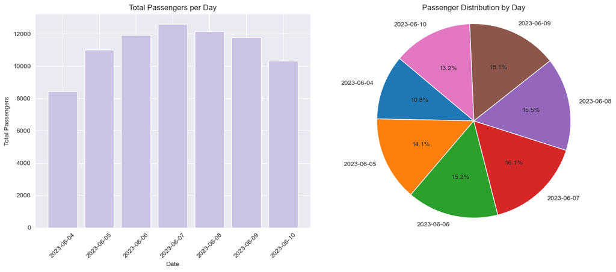

```python
# Group by 'Date' and sum the 'Passengers' for each day
daily_passengers = df.groupby('Date')['Passengers'].sum().reset_index()

# Set up a 1x2 grid for side-by-side plots
fig, axes = plt.subplots(1, 2, figsize=(14, 6))

# Bar chart on the left
axes[0].bar(daily_passengers['Date'], daily_passengers['Passengers'], color='#CBC3E3')
axes[0].set_xlabel('Date')
axes[0].set_ylabel('Total Passengers')
axes[0].set_title('Total Passengers per Day')
axes[0].tick_params(axis='x', rotation=45)  # Rotate date labels

# Pie chart on the right
axes[1].pie(daily_passengers['Passengers'], labels=daily_passengers['Date'], autopct='%1.1f%%', startangle=140)
axes[1].set_title('Passenger Distribution by Day')
axes[1].axis('equal')  # Ensure the pie chart is a circle

# Adjust layout for better spacing
plt.tight_layout()
plt.show()
```

The bar chart on the left displays the total number of passengers each day, making it easy to see daily fluctuations. June 7 (wednesday) had the highest passenger count, while June 4 (sunday) saw the fewest passengers.

On the right, the pie chart illustrates the percentage distribution of passengers across the week, with each slice representing a day. June 7 accounts for the largest share of weekly passengers (16.1%), while June 4 has the smallest share (10.8%). Together, these charts give a clear picture of daily passenger totals as well as the proportion of passengers each day contributed to the week’s total.

## Which ticket type is the most commonly used?

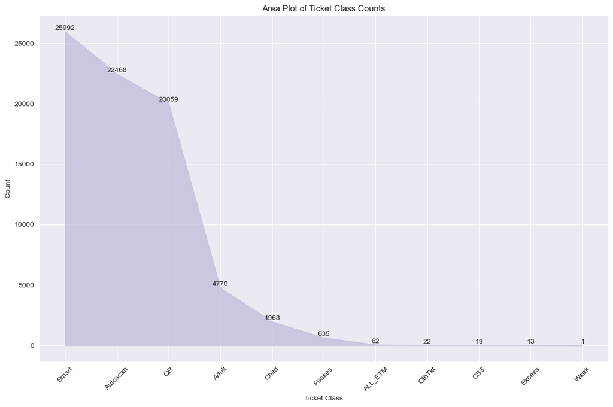

```python
# Adjust the area plot to make sure all ticket classes are visible
ticket_counts = df['Ticket Class'].value_counts()

# Creating a custom x-tick location and labels for categorical data
plt.figure(figsize=(12, 8))
plt.fill_between(range(len(ticket_counts)), ticket_counts.values, color='#beb9db', alpha=0.7)

# Add the count numbers at the top of the areas
for i, v in enumerate(ticket_counts.values):
    plt.text(i, v + 5, str(v), ha='center', va='bottom', fontsize=10)

# Adjust the plot to make sure the x-axis is categorical and all ticket classes are visible
plt.title('Area Plot of Ticket Class Counts')
plt.xlabel('Ticket Class')
plt.ylabel('Count')
plt.xticks(range(len(ticket_counts)), ticket_counts.index, rotation=45)  # Rotate x-axis labels for better readability
plt.tight_layout()  # Adjust layout to avoid clipping
plt.show()
```

#### 'Smart' Tickets are the most popular among the 11 ticket types from 04/06/2023 to 10/06/2023. 'Smart' with 'Autoscan' and 'QR' are three predominant tickets.

## Let us find out the popularities of the sub-category of the three popular ticket types.

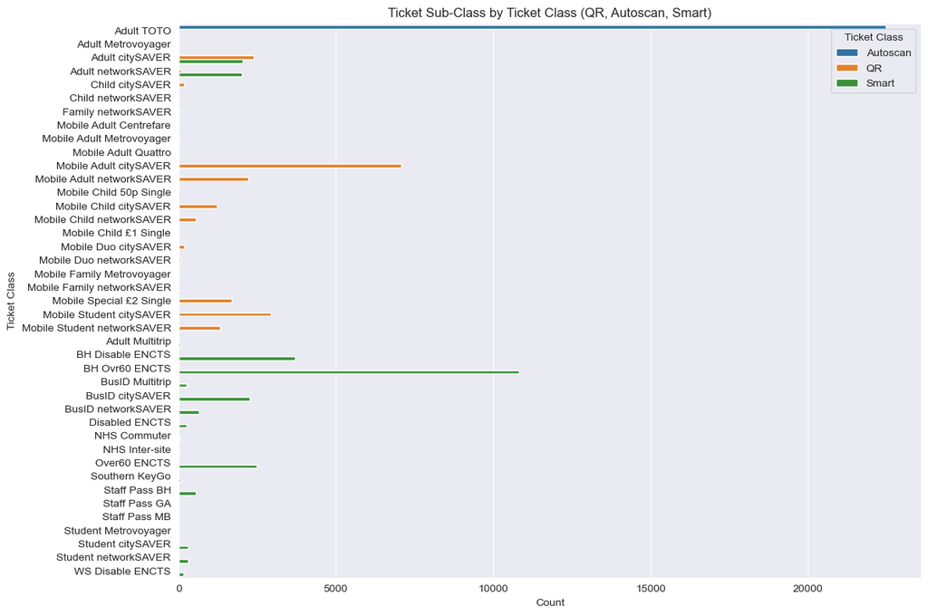

```python
# List of ticket classes you want to display
ticket_classes_to_show = ['QR', 'Autoscan', 'Smart']

# Filter the DataFrame for only the selected ticket classes
filtered_df = df[df['Ticket Class'].isin(ticket_classes_to_show)]

# Count the occurrences of each 'Ticket Description' within the filtered data
ticket_counts = filtered_df.groupby(['Ticket Class', 'Ticket Sub-Class']).size().reset_index(name='Count')

# Plotting the results
plt.figure(figsize=(12, 8))
sns.barplot(x='Count', y='Ticket Sub-Class', hue='Ticket Class', data=ticket_counts, orient='h')

# Adding labels and title
plt.xlabel('Count')
plt.ylabel('Ticket Class')
plt.title('Ticket Sub-Class by Ticket Class (QR, Autoscan, Smart)')
plt.tight_layout()
plt.show()
```

The QR ticket category includes a variety of ticket types, primarily aimed at adults, students, and special categories, with "M_Adult CitySvr" (7065 tickets) being the most popular, followed by other network saver and special fare tickets. The Autoscan category, on the other hand, is simpler, featuring just one ticket type, "Adult TOTO," which has a very high popularity with 22,468 tickets sold. The Smart ticket category offers a range of options, including senior and disability-related tickets like "BH Ovr60 ENCTS" (10,809 tickets) and various travel saver options for adults and staff.

# Which payment method is quicker or slower? What is the average transaction time of different ticket types?

To derive this, first transaction time for each ticket type in seconds is calculated. A new column called 'T_time' (in seconds) is created by grouping the ticket data by 'Bus Stop', 'Trip Number', and 'Date', and then subtracting their subsequent 'Transaction Time' values from each other. Note that 'Transaction Time' refers to the actual recorded time, while 'T_time' represents the overall time taken by a ticket type

```python
# Make a copy of the original DataFrame
df3 = df.copy()

#Sort by 'Bus Stop', 'Date', 'Trip Number', and 'Transaction Time'
df3 = df3.sort_values(by=["Date","Trip Number","Transaction Time",'Bus Stop'])

# Convert 'Transaction Time' column to datetime
#df3['Transaction Time'] = pd.to_datetime(df3['Transaction Time'])
df3['Transaction Time'] = pd.to_datetime(df3['Transaction Time'], format='%H:%M:%S')

# Calculate the time difference between consecutive rows
df3['T_time'] = df3.groupby(['Bus Stop', 'Date', 'Trip Number'])['Transaction Time'].diff().dt.total_seconds().fillna(0)

# Convert the 'Transaction Time' column back to time format
df3['Transaction Time'] = df3['Transaction Time'].dt.time

# Print the DataFrame head to check the results
df3.head()
```

|  | Bus Stop | Date | Transaction Time | Ticket Class | Trip Number | Ticket Sub-Class | Net | Tickets | Pass | Conc | Passengers | T_time |
| --- | --- | --- | --- | --- | --- | --- | --- | --- | --- | --- | --- | --- |
| 2232 | Brighton Marina | 2023-06-04 | 05:15:59 | QR | 1 | Mobile Adult citySAVER | 0.0 | 0 | 1 | 0 | 1 | 0.0 |
| 2233 | Brighton Marina | 2023-06-04 | 05:16:09 | Autoscan | 1 | Adult TOTO | 0.0 | 1 | 0 | 0 | 1 | 10.0 |
| 2234 | Brighton Marina | 2023-06-04 | 05:16:23 | Smart | 1 | BH Disable ENCTS | 0.0 | 0 | 0 | 1 | 1 | 14.0 |
| 2235 | Brighton Marina | 2023-06-04 | 05:19:32 | QR | 1 | Mobile Student networkSAVER | 0.0 | 0 | 1 | 0 | 1 | 189.0 |
| 2236 | Brighton Marina | 2023-06-04 | 05:19:36 | QR | 1 | Mobile Student networkSAVER | 0.0 | 0 | 1 | 0 | 1 | 4.0 |

```python
df3['T_time'].describe().T
```

```
count    76009.000000
mean         8.805655
std        319.759950
min          0.000000
25%          0.000000
50%          4.000000
75%          6.000000
max      86304.000000
Name: T_time, dtype: float64
```

Clearly, there are some extreme observations, as the maximum value is 86,304, which is very high. To identify these large data points, the column was filtered using the mean plus the standard deviation of the column. A total of 55 such observations were found and subsequently removed from the data.

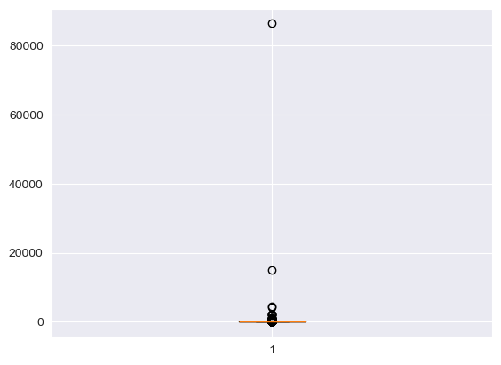

```python
plt.boxplot(df3['T_time'])
plt.show()
```

```python
#Transaction time anomalies detection
# Calculate mean and standard deviation
mean_T_time = df3['T_time'].mean()
std_T_time = df3['T_time'].std()

# Define threshold for anomalies
threshold =  std_T_time

# Find anomalies
anomalies = df3[df3['T_time'] > mean_T_time + threshold]

# Print the number of anomalies
print("Number of anomalies:", len(anomalies))

print("Time of anomalies:")
print(anomalies[['Bus Stop','Transaction Time','T_time','Ticket Class']])
```

```
Number of anomalies: 55
Time of anomalies:
                        Bus Stop Transaction Time   T_time Ticket Class
33609     George Street (stop J)         17:07:00    332.0        Smart
33616     George Street (stop J)         17:17:06    337.0        Smart
33658     George Street (stop J)         20:06:14    494.0           QR
33698     George Street (stop J)         06:32:49    423.0     Autoscan
31616              Eaton Gardens         10:02:10    341.0     Autoscan
15918  Brighton Station (stop E)         13:17:01   2107.0        Smart
34262     George Street (stop J)         15:08:47    376.0        Smart
39296               Hove Station         19:04:50    778.0        Smart
34504     George Street (stop J)         05:19:05    412.0        Smart
684                 Arundel Road         09:53:24    338.0        Smart
5232             Brighton Marina         18:25:30  15061.0        Child
39640               Hove Station         15:38:52    792.0        Smart
```

[output cut: 43 more lines]

```python
#Dropping the 'Transaction time' anomalies
# Calculate mean and standard deviation
mean_T_time = df3['T_time'].mean()
std_T_time = df3['T_time'].std()

# Define threshold for anomalies
threshold = std_T_time

# Find indices of anomalies
anomalies = df3[df3['T_time'] > mean_T_time + threshold].index

# Drop rows with anomalies
df3.drop(index=anomalies, inplace=True)

# Print the updated DataFrame information
print("Number of rows after dropping anomalies:", len(df3))
```

```
Number of rows after dropping anomalies: 75954
```

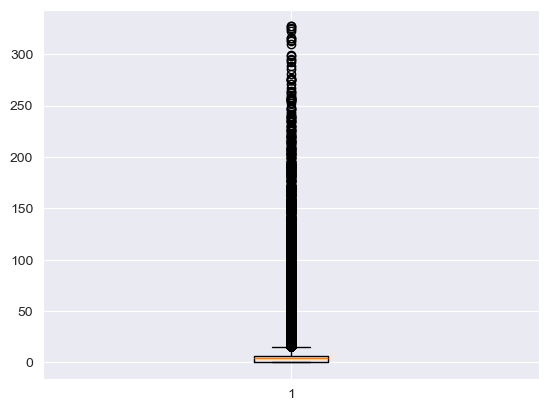

```python
plt.boxplot(df3['T_time'])
plt.show()
```

After this, the total transaction time for each type of ticket was calculated. Then, the total transaction time was divided by the total count of each ticket type to find the average transaction time.

```python
'''# Group by 'Ticket Description' and calculate total time and ticket count
total_time_and_count_by_class = df3.groupby('Ticket Class')['T_time'].agg(['sum', 'count']).abs().reset_index()
total_time_and_count_by_class.rename(columns={'sum': 'Total Time', 'count': 'Ticket Count'}, inplace=True)

# Calculate average time
total_time_and_count_by_class['Average Time'] = total_time_and_count_by_class['Total Time'] / total_time_and_count_by_class['Ticket Count']

# Sort the results by 'Average Time' in descending order
total_time_and_count_by_class_sorted = total_time_and_count_by_class.sort_values(by='Average Time', ascending=True)

# Display the sorted result
print("Average time by Ticket Class(sorted):")
print(total_time_and_count_by_class_sorted)
'''
```

[output not shown]

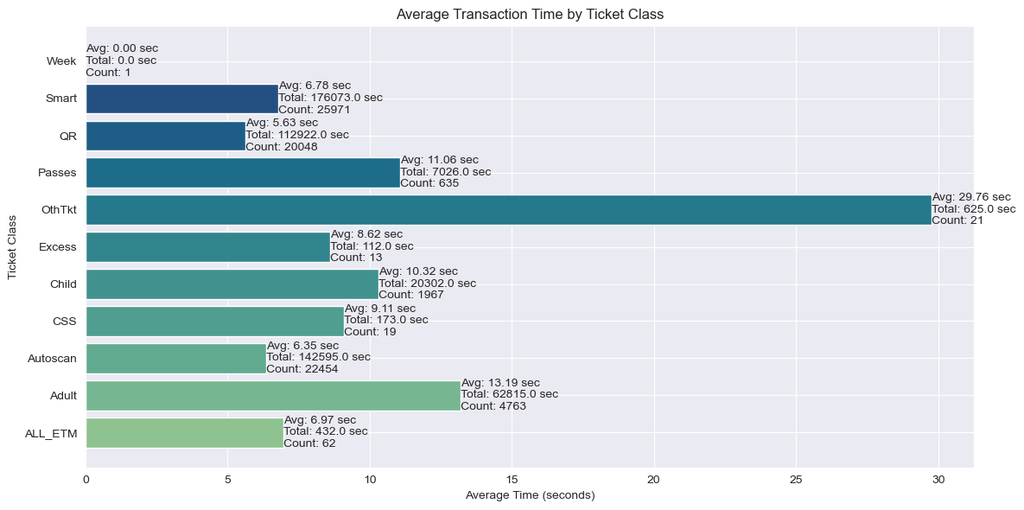

```python
# Group by 'Ticket Class Description' and calculate average time
total_time_and_count_by_class = df3.groupby('Ticket Class')['T_time'].agg(['sum', 'count']).abs().reset_index()
total_time_and_count_by_class.rename(columns={'sum': 'Total Time', 'count': 'Ticket Count'}, inplace=True)

total_time_and_count_by_class.sort_values(by='Ticket Count')

# Calculate average time
total_time_and_count_by_class['Average Time'] = total_time_and_count_by_class['Total Time'] / total_time_and_count_by_class['Ticket Count']

plt.figure(figsize=(12, 6))
bars = plt.barh(total_time_and_count_by_class['Ticket Class'], total_time_and_count_by_class['Average Time'], color=sns.color_palette("crest", len(ticket_counts)))
plt.ylabel('Ticket Class')
plt.xlabel('Average Time (seconds)')
plt.title('Average Transaction Time by Ticket Class')

# Add the average time, total time, and ticket count labels on the bars
for index, bar in enumerate(bars):
    plt.text(
        bar.get_width(),  # x-coordinate position of the text
        bar.get_y() + bar.get_height() / 2,  # y-coordinate position of the text
        f'Avg: {bar.get_width():.2f} sec\nTotal: {total_time_and_count_by_class["Total Time"].iloc[index]} sec\nCount: {total_time_and_count_by_class["Ticket Count"].iloc[index]}',
        # text to display (formatted to 2 decimal places)
        va='center',  # vertical alignment
        ha='left',  # horizontal alignment
        fontsize=10  # font size
    )

plt.tight_layout()  # Adjust layout to ensure everything fits without overlap
plt.show()
```

Examining the average transaction time for each ticket type provided insights into transaction efficiency and processing durations. For instance, 'QR' tickets exhibited the shortest average transaction time, while 'OthTkt' and 'Adult' tickets had comparatively longer transaction durations. Although, ‘Smart’ 14 ticket has third lowest ticket time, interesting to note that, it has the highest ticket counts among all. Understanding transaction time variations among ticket types can inform strategies to streamline ticketing processes and reduce passenger wait times.

# How long the buses are at each stop for and what tickets were being used?

While extracting dwell time from the GPS dataset, issues with 'Actual Arrival Time' and 'Actual Departure Time' were found due to inconsistent datetime formats. These anomalies were corrected, and dwell times were then calculated for each bus stop.

```python
GPS_df=GPS.copy()

# Function to check anomalies
def check_anomalies(column):
    anomalies = []
    for value in column:
        value_str = str(value)
        if len(value_str) != 8:  # Check if the length of the string representation is not equal to 'HH:MM:SS'
            anomalies.append(value_str)
    return anomalies

# Check anomalies in 'Actual Arrival Time'
arrival_anomalies = check_anomalies(GPS_df['Actual Arrival Time'])

# Check anomalies in 'Actual Departure Time'
departure_anomalies = check_anomalies(GPS_df['Actual Departure Time'])

print("Anomalies in Actual Arrival Time:", arrival_anomalies)
print("Anomalies in Actual Departure Time:", departure_anomalies)
```

```
Anomalies in Actual Arrival Time: ['1900-01-01 00:00:18', '1900-01-01 00:01:36', '1900-01-01 00:02:27', '1899-12-29 23:59:41', '1900-01-01 00:00:44', '1900-01-01 00:02:33', '1899-12-29 23:59:35', '1900-01-01 00:00:40', '1900-01-01 00:01:23', '1899-12-29 23:57:59', '1899-12-29 23:59:55', '1900-01-01 …
Anomalies in Actual Departure Time: ['1900-01-01 00:00:46', '1900-01-01 00:02:12', '1900-01-01 00:02:31', '1899-12-29 23:59:41', '1900-01-01 00:01:28', '1900-01-01 00:03:07', '1900-01-01 00:01:27', '1900-01-01 00:00:01', '1900-01-01 00:02:32', '1899-12-29 23:59:26', '1899-12-29 23:59:55', '1900-01-0…
```

```python
# Function to check anomalies and convert datetime to time format
def convert_anomalies_to_time_format(df):
    for col in ['Actual Arrival Time', 'Actual Departure Time']:
        for idx, value in enumerate(df[col]):
            value_str = str(value)
            if len(value_str) != 8:  # Check if the length of the string representation is not equal to 'HH:MM:SS'
                df.at[idx, col] = value_str.split()[1]  # Extract only the time part

# Create a copy of the original DataFrame to avoid modifying it
GPS_df = GPS.copy()

# Convert anomalies in 'Actual Arrival Time' and 'Actual Departure Time' columns to time format
convert_anomalies_to_time_format(GPS_df)
```

```python
# Function to check anomalies
def check_anomalies(column):
    anomalies = []
    for value in column:
        value_str = str(value)
        if len(value_str) != 8:  # Check if the length of the string representation is not equal to 'HH:MM:SS'
            anomalies.append(value_str)
    return anomalies

# Check anomalies in 'Actual Arrival Time'
arrival_anomalies = check_anomalies(GPS_df['Actual Arrival Time'])

# Check anomalies in 'Actual Departure Time'
departure_anomalies = check_anomalies(GPS_df['Actual Departure Time'])

print("Anomalies in Actual Arrival Time:", arrival_anomalies)
print("Anomalies in Actual Departure Time:", departure_anomalies)
```

```
Anomalies in Actual Arrival Time: []
Anomalies in Actual Departure Time: []
```

```python
#GPS_df['Actual Arrival Time'] = pd.to_datetime(GPS_df['Actual Arrival Time'])
#GPS_df['Actual Departure Time'] = pd.to_datetime(GPS_df['Actual Departure Time'])

GPS_df['Actual Arrival Time'] = pd.to_datetime(GPS_df['Actual Arrival Time'], format='%H:%M:%S')
GPS_df['Actual Departure Time'] = pd.to_datetime(GPS_df['Actual Departure Time'], format='%H:%M:%S')

# Calculate the time spent at each stop in seconds
GPS_df['Dwell time'] = GPS_df.apply(lambda row: (row['Actual Departure Time'].hour * 3600 + row['Actual Departure Time'].minute * 60 + row['Actual Departure Time'].second) -
                                                             (row['Actual Arrival Time'].hour * 3600 + row['Actual Arrival Time'].minute * 60 + row['Actual Arrival Time'].second) if row['Actual Departure Time'] >= row['Actual Arrival Time'] else
                                                             (row['Actual Departure Time'].hour * 3600 + row['Actual Departure Time'].minute * 60 + row['Actual Departure Time'].second + 24*3600) -
                                                             (row['Actual Arrival Time'].hour * 3600 + row['Actual Arrival Time'].minute * 60 + row['Actual Arrival Time'].second), axis=1)

# Display the dataframe
GPS_df.head()
```

|  | Block_No | Direction | Timing Point | Bus number | Location No | Bus Stop | Date | Planned Arrival Time | Planned Departure Time | Actual Arrival Time | Actual Departure Time | Dwell time |
| --- | --- | --- | --- | --- | --- | --- | --- | --- | --- | --- | --- | --- |
| 0 | 501 | 1 | Timing Point | 322 | 756(0) | Brighton Marina | 2023-06-04 | 05:20:00 | 05:20:00 | 1900-01-01 05:20:05 | 1900-01-01 05:20:05 | 0 |
| 1 | 501 | 1 | Timing Point | 322 | 428(0) | Arundel Road | 2023-06-04 | 05:22:00 | 05:22:00 | 1900-01-01 05:22:11 | 1900-01-01 05:22:40 | 29 |
| 2 | 501 | 1 | NonTiming Point | 322 | 427(1) | LiDL Superstore | 2023-06-04 | 05:22:23 | 05:22:23 | 1900-01-01 05:22:56 | 1900-01-01 05:23:01 | 5 |
| 3 | 501 | 1 | NonTiming Point | 322 | 437(0) | Sussex Square | 2023-06-04 | 05:23:04 | 05:23:04 | 1900-01-01 05:23:19 | 1900-01-01 05:23:51 | 32 |
| 4 | 501 | 1 | NonTiming Point | 322 | 426(1) | St Marys Hall | 2023-06-04 | 05:23:48 | 05:23:48 | 1900-01-01 05:24:11 | 1900-01-01 05:24:15 | 4 |

```python
GPS_df['Dwell time'].describe()
```

```
count    40726.000000
mean        44.940456
std         67.852695
min          0.000000
25%         14.000000
50%         31.000000
75%         50.000000
max       3223.000000
Name: Dwell time, dtype: float64
```

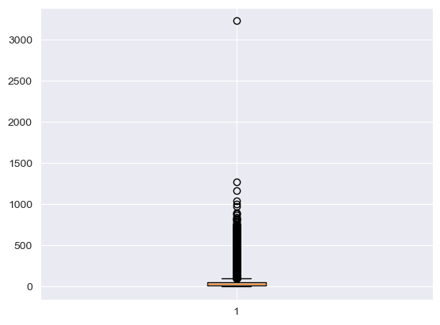

```python
plt.boxplot(GPS_df['Dwell time'])
plt.show()
```

```python
# Calculate mean and standard deviation
mean_T_time =GPS_df['Dwell time'].mean()
std_T_time = GPS_df['Dwell time'].std()

# Define threshold for anomalies
threshold =  3*std_T_time

# Find anomalies
anomalies = GPS_df[GPS_df['Dwell time'] > mean_T_time + threshold]

# Print the number of anomalies
print("Number of anomalies:", len(anomalies))

print("Time of anomalies:")
print(anomalies[['Bus Stop','Dwell time']])
```

```
Number of anomalies: 618
Time of anomalies:
                     Bus Stop  Dwell time
296    George Street (stop J)         367
350    George Street (stop J)         740
404    George Street (stop J)         315
445    George Street (stop J)         452
499    George Street (stop J)         562
...                       ...         ...
40457  George Street (stop J)         265
40511  George Street (stop J)         255
40565  George Street (stop J)         813
40618  George Street (stop J)         296
40672  George Street (stop J)         559

[618 rows x 2 columns]
```

```python
# Count the number of observations where 'Dwell time' is greater than 700 seconds
anomalies = len(GPS_df[GPS_df['Dwell time'] >= 700])

print(anomalies)
```

```
51
```

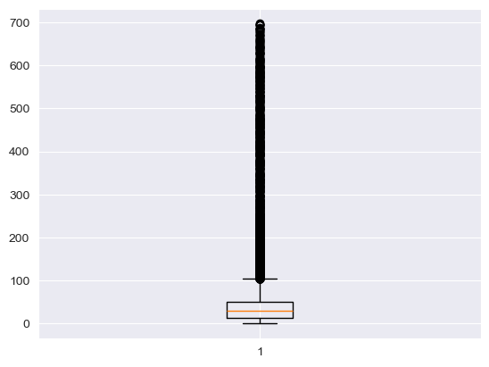

```python
# Filter rows where 'Dwell time' is greater than or equal to your desirable seconds
rows_to_delete = GPS_df[GPS_df['Dwell time'] >= 700]

# Drop the filtered rows from the original DataFrame
GPS_df = GPS_df.drop(rows_to_delete.index)

# Optional: Reset the index of the DataFrame after dropping rows
GPS_df = GPS_df.reset_index(drop=True)

# Display the updated DataFrame
plt.boxplot(GPS_df['Dwell time'])
plt.show()
```

## Duration of each stop made by the buses?

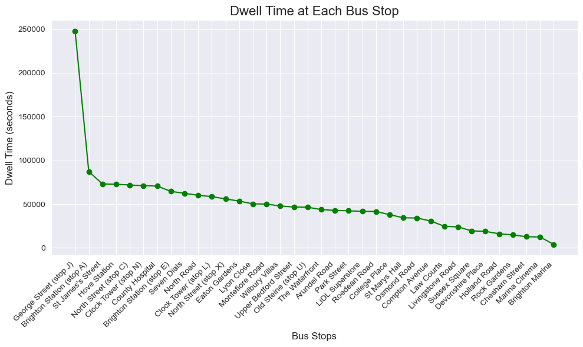

```python
# Group by 'Bus Stop' and sum the 'Dwell time'
total_time_spent_by_location = GPS_df.groupby('Bus Stop')['Dwell time'].sum().reset_index()

# Sort the data by 'Dwell time' in descending order
total_time_spent_by_location = total_time_spent_by_location.sort_values('Dwell time', ascending=False)

# Calculate the cumulative sum of dwell time
#total_time_spent_by_location['Cumulative Dwell Time'] = total_time_spent_by_location['Dwell time'].cumsum()

# Plot the cumulative dwell time
plt.figure(figsize=(10, 6))
plt.plot(total_time_spent_by_location['Bus Stop'], total_time_spent_by_location['Dwell time'], marker='o', color='g')

# Add labels and title
plt.title('Dwell Time at Each Bus Stop', fontsize=16)
plt.xlabel('Bus Stops', fontsize=12)
plt.ylabel('Dwell Time (seconds)', fontsize=12)
plt.xticks(rotation=45, ha='right', va='top')  # Rotate bus stop names for readability

plt.tight_layout()
plt.show()
```

Following this calculation, dwell time values were aggregated according to bus stops. It appears that at the beginning of the journey, such as at **George Street**, buses may experience longer transaction and dwell times. This could be due to the assumption that buses arrive early at the first stop to pick up passengers, leading to longer transaction times as passengers board and tickets are processed. Consequently, there may be longer intervals between consecutive ticket transactions during this initial phase of the journey.

## Ticket Class Preferences at Bus Stops?

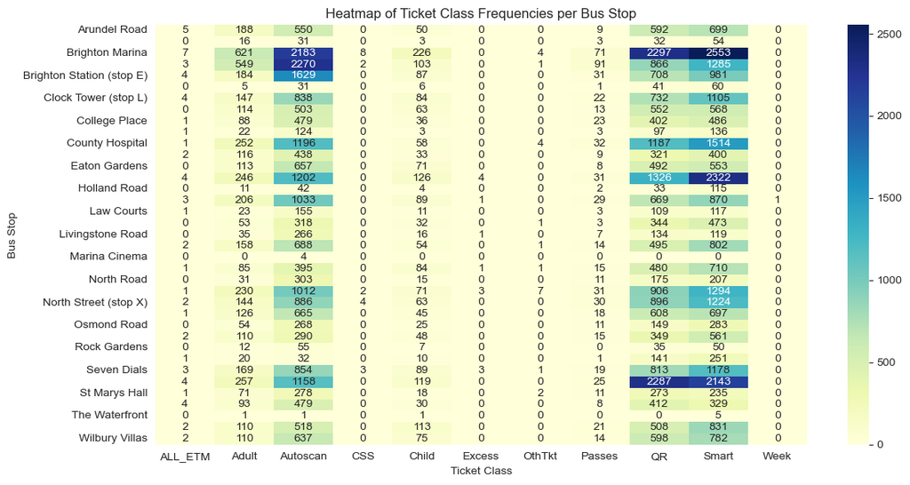

```python
import seaborn as sns
import matplotlib.pyplot as plt

# Pivot the data to create a matrix of ticket class counts per bus stop
ticket_matrix = ticketer.groupby(['Bus Stop', 'Ticket Class']).size().unstack(fill_value=0)

# Plot the heatmap
plt.figure(figsize=(12, 6))
sns.heatmap(ticket_matrix, annot=True, cmap='YlGnBu', fmt='d')

plt.title('Heatmap of Ticket Class Frequencies per Bus Stop')
plt.xlabel('Ticket Class')
plt.ylabel('Bus Stop')
plt.tight_layout()
plt.show()
```

An interesting finding is that **Smart** and **Autoscan** tickets dominate most stops, except at **St James’s Street**, where **QR** tickets are more popular. This unique pattern might reflect specific demographics around Stop J. Exploring the area’s demographics could offer valuable insights into passenger preferences and behaviors at this location.

## Which stop experiences the highest customer frequency?

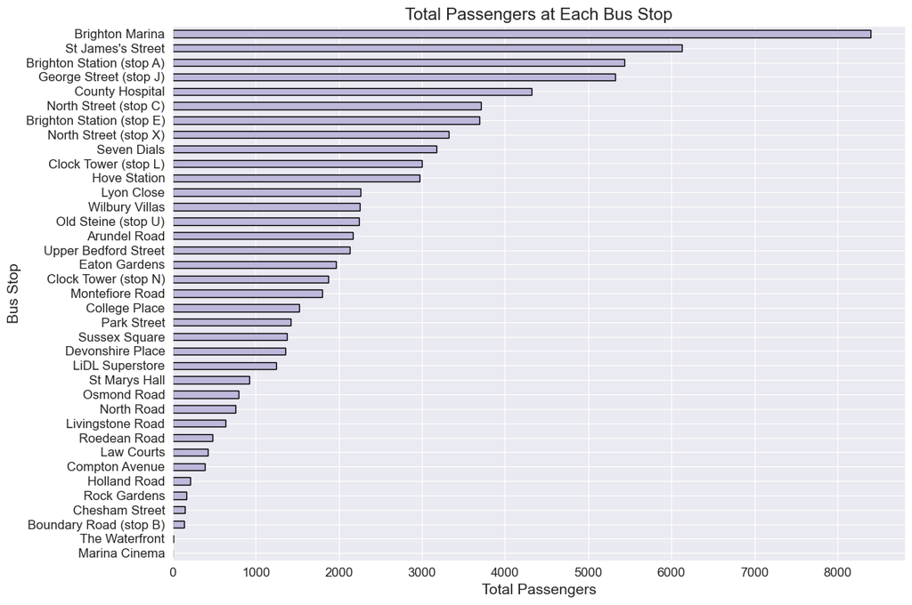

```python
# Group and sum passengers at each stop
passengers_at_stops = df.groupby('Bus Stop')['Passengers'].sum().sort_values(ascending=False)

# Create the visualization
plt.figure(figsize=(12, 8))
passengers_at_stops.plot(kind='barh', color='#beb9db', edgecolor='black')

# Enhance the plot
plt.title('Total Passengers at Each Bus Stop', fontsize=16)
plt.xlabel('Total Passengers', fontsize=14)
plt.ylabel('Bus Stop', fontsize=14)
plt.gca().invert_yaxis()  # Invert y-axis to have the highest value at the top
plt.xticks(fontsize=12)
plt.yticks(fontsize=12)
plt.tight_layout()

# Show the plot
plt.show()
```

## Which time of the day is the bus-iest?

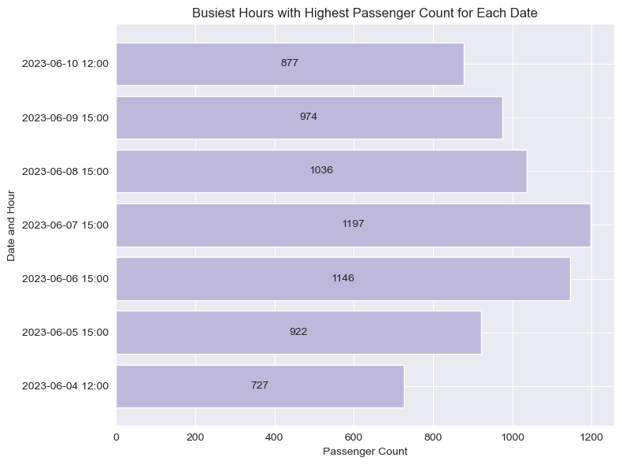

```python
# Specify the format of 'Transaction Time' if known (update '%Y-%m-%d %H:%M:%S' based on your data)
#ticketer['Transaction Time'] = pd.to_datetime(ticketer['Transaction Time'], format='%Y-%m-%d %H:%M:%S')
ticketer['Transaction Time'] = pd.to_datetime(ticketer['Transaction Time'], format='%H:%M:%S')


# Extract hour from 'Transaction Time'
ticketer['Hour'] = ticketer['Transaction Time'].dt.hour

# Group by date and hour, then sum the passenger count
busiest_hours = ticketer.groupby(['Date', 'Hour'])['Passengers'].sum().reset_index()

# Find the hour with the highest passenger count for each date
busiest_hours = busiest_hours.loc[busiest_hours.groupby('Date')['Passengers'].idxmax()]

# Visualize the busiest hours
plt.figure(figsize=(8, 6))
bars = plt.barh(busiest_hours['Date'].astype(str) + ' ' + busiest_hours['Hour'].astype(str) + ':00',
                busiest_hours['Passengers'], color='#beb9db')
plt.ylabel('Date and Hour')
plt.xlabel('Passenger Count')
plt.title('Busiest Hours with Highest Passenger Count for Each Date')

# Add the passenger count labels inside the bars
for index, bar in enumerate(bars):
    plt.text(
        bar.get_width() / 2,  # x-coordinate position of the text (inside the bar)
        bar.get_y() + bar.get_height() / 2,  # y-coordinate position of the text (inside the bar)
        f'{int(bar.get_width())}',  # text to display (passenger count)
        ha='center',  # horizontal alignment
        va='center',  # vertical alignment
        fontsize=10  # font size
    )

plt.tight_layout()
plt.show()
```

## Table Joins

```python
df3['Transaction Time'] = df3['Transaction Time'].apply(lambda x: x.strftime('%H:%M:%S'))
Concess['Transaction Time'] = Concess['Transaction Time'].astype(str)
```

```python
# Bring the Date columns in common format
df3['Date'] = pd.to_datetime(df3['Date'])
Concess['Date'] = pd.to_datetime(Concess['Date'])

# Perform left join using merge function
ticket_data = pd.merge(Concess,df3,on=['Ticket Sub-Class','Transaction Time','Date','Trip Number'], how='inner')
```

Merging ticket-type data from E.P. Morris and Ticketer, focusing on retaining all bus stop information. Key columns like 'Ticket Sub-Class,' 'Transaction Time,' 'Date,' and 'Trip Number' were standardized for alignment. Duplicate entries were removed to ensure clean, integrated data.

The ticket data was then joined with GPS data based on common fields such as 'Bus Stop', 'Bus Number', and 'Date'. This step aimed to enrich the ticket data with geographical information. Redundant or unnecessary columns such as 'Route Number', 'Operator', 'Number', 'Value of Ride', 'Custom Formula', 'ETM Route Code', 'Route Number', and 'Route Description' were dropped. These columns either contained null values or redundant information.

```python
#GPS_df['Date'] = pd.to_datetime(GPS_df['Date'])
model_data = pd.merge(ticket_data,GPS_df, on=['Bus Stop','Bus number','Date'], how='inner')
```

### Creating four distinct categories from 'Ticket Class'

```python
# Define a function to map the ticket classes to the desired categories
def map_category(ticket_class):
    if ticket_class in ['Adult', 'Child','OthTkt']:
        return 'Cash'
    elif ticket_class == 'Autoscan':
        return 'TOTO'
    elif ticket_class in ['Smart','Passes','Excess']:
        return 'Keycard'
    elif ticket_class in ['QR','CSS','Week']:
        return 'Mobile App'

# Create new columns based on the mapping
model_data['Cash'] = model_data['Ticket Class'].apply(lambda x: x if map_category(x) == 'Cash' else None)
model_data['TOTO'] = model_data['Ticket Class'].apply(lambda x: x if map_category(x) == 'TOTO' else None)
model_data['Keycard'] = model_data['Ticket Class'].apply(lambda x: x if map_category(x) == 'Keycard' else None)
model_data['Mobile App'] = model_data['Ticket Class'].apply(lambda x: x if map_category(x) == 'Mobile App' else None)

#model_data.drop(columns=['Ticket Class Description'], inplace=True)

# Display the resulting DataFrame
model_data.head(2)
```

|  | Trip Number | Date | Transaction Time | Ticket Sub-Class | Fare Paid | Origin Stop | Destination Stop | Bus number | Duty number | Shadow | ... | Location No | Planned Arrival Time | Planned Departure Time | Actual Arrival Time | Actual Departure Time | Dwell time | Cash | TOTO | Keycard | Mobile App |
| --- | --- | --- | --- | --- | --- | --- | --- | --- | --- | --- | --- | --- | --- | --- | --- | --- | --- | --- | --- | --- | --- |
| 0 | 1 | 2023-06-04 | 05:15:59 | Mobile Adult citySAVER | 0.0 | 222 | 222 | 322 | 3003 | 0.0 | ... | 756(0) | 05:20:00 | 05:20:00 | 1900-01-01 05:20:05 | 1900-01-01 05:20:05 | 0 | None | None | None | QR |
| 1 | 1 | 2023-06-04 | 05:15:59 | Mobile Adult citySAVER | 0.0 | 222 | 222 | 322 | 3003 | 0.0 | ... | 756(0) | 06:20:00 | 06:20:00 | 1900-01-01 06:20:00 | 1900-01-01 06:20:00 | 0 | None | None | None | QR |

2 rows × 31 columns

### Fill missing values with 0 and assign back to the column

```python
# Fill missing values with 0 and assign back to the column
model_data['Cash'] = model_data['Cash'].fillna(0)
model_data['TOTO'] = model_data['TOTO'].fillna(0)
model_data['Keycard'] = model_data['Keycard'].fillna(0)
model_data['Mobile App'] = model_data['Mobile App'].fillna(0)
```

# Modeling

```python
model_data['Actual Arrival Time'] = model_data['Actual Arrival Time'].dt.time
model_data['Actual Departure Time'] = model_data['Actual Departure Time'].dt.time
```

```python
model_data['Dwell time'].describe().T
```

```
count    925976.000000
mean         59.140868
std          85.888332
min           0.000000
25%          21.000000
50%          37.000000
75%          67.000000
max         697.000000
Name: Dwell time, dtype: float64
```

```python
model_data = model_data.drop_duplicates()
```

### Finding anomalies/extreme value if any

```python
# Drop rows where 'T_time' is greater than 'Dwell time'
model_data = model_data[model_data['T_time'] <= model_data['Dwell time']]

# Verify the number of rows after dropping
count_remaining_rows = model_data.shape[0]

print(f"Number of rows remaining after dropping: {count_remaining_rows}")
```

```
Number of rows remaining after dropping: 812728
```

```python
# Identify numeric columns in the DataFrame
numeric_columns = ['Net', 'Fare Paid', 'Shadow', 'T_time']  # Only numeric columns
# Convert numeric columns to integers (ensure there are no missing values in these columns before converting)
model_data[numeric_columns] = model_data[numeric_columns].fillna(0).astype(int)

# Identify categorical columns that should be encoded (example: 'Ticket Class', 'Bus Stop')
categorical_columns = ['Cash', 'TOTO', 'Keycard', 'Mobile App', 'Bus Stop', 'Timing Point','Location No']  # These are usually strings

# Encode categorical columns if needed (example: Label Encoding)
from sklearn.preprocessing import LabelEncoder

le = LabelEncoder()
for col in categorical_columns:
    model_data[col] = le.fit_transform(model_data[col].astype(str))  # Ensure they are strings before encoding
```

### Encoding

```python
from sklearn.preprocessing import LabelEncoder

# Define columns to encode
columns_to_encode = ['Mobile App','TOTO','Cash','Keycard','Location No',
                'Timing Point','Origin Stop','Direction','Bus Stop','Date']



# Create LabelEncoder instance
label_encoder = LabelEncoder()

# Apply LabelEncoder to each specified column
for column in columns_to_encode:
    model_data[column] = label_encoder.fit_transform(model_data[column])
```

### Correlation

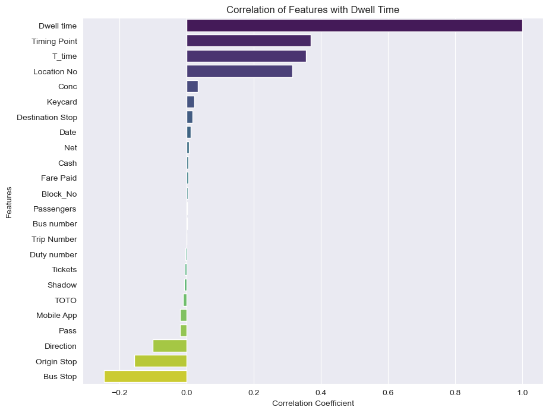

```python
# Filter numeric columns only
numeric_data = model_data.select_dtypes(include=[np.number])

# Calculate the correlation matrix
correlation_matrix = numeric_data.corr()

# Extract correlations with 'Dwell time' and sort them
if 'Dwell time' in correlation_matrix.columns:
    dwell_time_correlation = correlation_matrix['Dwell time'].sort_values(ascending=False)
else:
    raise ValueError("'Dwell time' column not found in numeric data.")

# Plot the sorted correlation values
plt.figure(figsize=(10, 8))
sns.barplot(
    x=dwell_time_correlation.values,
    y=dwell_time_correlation.index,
    hue=dwell_time_correlation.index,
    palette="viridis",
    legend=False  # Suppress the legend
)

# Add titles and labels
plt.title('Correlation of Features with Dwell Time')
plt.xlabel('Correlation Coefficient')
plt.ylabel('Features')

# Show the plot
plt.show()
```

### Nested Machine Learning Model - KNN, XGBoost, Random Forest

```python
from sklearn.model_selection import train_test_split
from sklearn.linear_model import LinearRegression
from sklearn.ensemble import RandomForestRegressor
from xgboost import XGBRegressor
from sklearn.neighbors import KNeighborsRegressor
from sklearn.metrics import mean_squared_error, mean_absolute_error, r2_score

# Split data into train and test sets
X = model_data[['Location No','T_time','Mobile App','TOTO','Cash','Keycard','Passengers',
                'Timing Point','Origin Stop','Direction','Bus Stop','Destination Stop','Date',
                'Block_No',
                ]]
y = model_data['Dwell time']
X_train, X_test, y_train, y_test = train_test_split(X, y, test_size=0.2, random_state=42)

# Initialize and train the models
models = {
    "Linear Regression": LinearRegression(),
    "Random Forest Regression": RandomForestRegressor(),
    "XGBoost Regression": XGBRegressor(),
    "KNeighbor Regression": KNeighborsRegressor(n_neighbors=5)
}


for name, model in models.items():
    model.fit(X_train, y_train)
    y_pred = model.predict(X_test)
    mse = mean_squared_error(y_test, y_pred)
    rmse = np.sqrt(mse)
    mae = mean_absolute_error(y_test, y_pred)
    r2 = r2_score(y_test, y_pred)
    print(f"{name} Metrics:")
    print(f"  Mean Squared Error: {mse:.2f}")
    print(f"  Root Mean Squared Error: {rmse:.2f}")
    print(f"  Mean Absolute Error: {mae:.2f}")
    print(f"  R-squared: {r2:.2f}")
    print()
```

```
Linear Regression Metrics:
  Mean Squared Error: 5677.83
  Root Mean Squared Error: 75.35
  Mean Absolute Error: 42.53
  R-squared: 0.29

Random Forest Regression Metrics:
  Mean Squared Error: 2998.97
  Root Mean Squared Error: 54.76
  Mean Absolute Error: 29.03
  R-squared: 0.63

XGBoost Regression Metrics:
  Mean Squared Error: 2473.74
  Root Mean Squared Error: 49.74
  Mean Absolute Error: 26.72
  R-squared: 0.69

KNeighbor Regression Metrics:
  Mean Squared Error: 3222.98
  Root Mean Squared Error: 56.77
  Mean Absolute Error: 30.26
  R-squared: 0.60
```

### Cross-Validation - KNN, XGBoost, Random Forest

```python
import pandas as pd
from sklearn.model_selection import cross_val_score
from sklearn.model_selection import train_test_split
from sklearn.metrics import mean_squared_error, mean_absolute_error, r2_score
from sklearn.ensemble import RandomForestRegressor
from xgboost import XGBRegressor
from sklearn.neighbors import KNeighborsRegressor
import numpy as np

# Split data into train and test sets
X = model_data[['Location No','T_time','Mobile App','TOTO','Cash','Keycard','Passengers',
                'Timing Point','Origin Stop','Direction','Bus Stop','Destination Stop','Date','Block_No',]]

y = model_data['Dwell time']
X_train, X_test, y_train, y_test = train_test_split(X, y, test_size=0.2, random_state=42)

# Define regression models
models = {
    "Random Forest Regression": RandomForestRegressor(),
    "XGBoost Regression": XGBRegressor(),
    "KNeighbor Regression": KNeighborsRegressor(n_neighbors=5)
}

# Perform k-fold cross-validation for each model
for name, model in models.items():
    # Fit the model to the training data
    model.fit(X_train, y_train)

    # Perform 5-fold cross-validation
    scores = cross_val_score(model, X_train, y_train, cv=5, scoring='neg_mean_squared_error')

    # Convert negative MSE scores to positive
    scores = -scores

    # Calculate mean MSE and standard deviation
    mean_mse = scores.mean()
    std_mse = scores.std()

    # Calculate RMSE
    rmse = np.sqrt(mean_mse)

    # Calculate MAE
    mae = mean_absolute_error(y_test, model.predict(X_test))

    # Calculate R-squared
    r2 = model.score(X_test, y_test)

    # Print results
    print(f"{name}:\n")
    print(f"\tMean Squared Error: {mean_mse:.2f}")
    print(f"\tRoot Mean Squared Error: {rmse:.2f}")
    print(f"\tMean Absolute Error: {mae:.2f}")
    print(f"\tR-squared: {r2:.2f}\n")
```

```
Random Forest Regression:

	Mean Squared Error: 2975.19
	Root Mean Squared Error: 54.55
	Mean Absolute Error: 29.02
	R-squared: 0.63

XGBoost Regression:

	Mean Squared Error: 2421.75
	Root Mean Squared Error: 49.21
	Mean Absolute Error: 26.72
	R-squared: 0.69

KNeighbor Regression:

	Mean Squared Error: 3172.42
	Root Mean Squared Error: 56.32
	Mean Absolute Error: 30.26
	R-squared: 0.60
```

# Feature Importance

#### As XGBOOST giving the most R-Squared value let's do XGBOOST feature importance for the columns.

```python
from xgboost import XGBRegressor
from sklearn.model_selection import train_test_split
import pandas as pd

# Define feature names
feature_names = ['Location No','T_time','Mobile App','TOTO','Cash','Keycard','Passengers',
                'Timing Point','Origin Stop','Direction','Bus Stop','Destination Stop','Date','Block_No']


# Split data into train and test sets
X = model_data[feature_names]
y = model_data['Dwell time']
X_train, X_test, y_train, y_test = train_test_split(X, y, test_size=0.2, random_state=42)

# Initialize and fit the XGBoost model
xgb = XGBRegressor()
xgb.fit(X_train, y_train)

# Get feature importances from the model
xgb_feature_importances = xgb.feature_importances_

# Creating a DataFrame for better visualization
xgb_importances_df = pd.DataFrame({
    'Feature': feature_names,
    'Importance': xgb_feature_importances
}).sort_values(by='Importance', ascending=False)

print("XGBoost Feature Importances:")
print(xgb_importances_df)
```

```
XGBoost Feature Importances:
             Feature  Importance
0        Location No    0.618763
9          Direction    0.203192
7       Timing Point    0.081599
1             T_time    0.035325
8        Origin Stop    0.017053
12              Date    0.016931
13          Block_No    0.012093
10          Bus Stop    0.007513
6         Passengers    0.001518
4               Cash    0.001378
11  Destination Stop    0.001309
5            Keycard    0.001272
2         Mobile App    0.001082
3               TOTO    0.000973
```

Location No has the highest importance (0.618763), indicating that the location is a significant contributor to Dwell Time. Optimizing locations that have high dwell times could help reduce overall delays. Direction (0.203192) also has a notable effect, suggesting that certain directions, possibly related to routes or traffic conditions, cause longer dwell times. Improving the flow or scheduling in these directions could be beneficial. Timing Point (0.081599) comes next, showing that specific timing during the journey contributes to dwell time. Adjusting or optimizing timing at certain points can potentially reduce delays.

Other features such as T_time (0.035325) and Origin Stop (0.017053) also have relatively higher importance, meaning they play a role in increasing dwell time. Understanding the time spent at different stops or optimizing how long buses stay at certain stops could help reduce delays. Date (0.016931) and Block_No (0.012093) show minor importance, suggesting they don't significantly impact dwell time but might still be worth exploring for minor optimizations.

On the other hand, features with very low importance, such as TOTO (0.000973), Mobile App (0.001082), Keycard (0.001272), and Cash (0.001378), have little impact on increasing Dwell Time. These features likely don't contribute to delays and are therefore considered less critical in the context of reducing dwell time. Focusing on optimizing the factors with higher importance, such as Location No and Direction, would be more effective in reducing overall dwell time, while the low-importance features can be deprioritized.

# References

Ng, A. (1998). Preventing "Overfitting" of Cross-Validation Data. Proceedings of the Fourteenth International Conference on Machine Learning.

Moreno-Torres, J., Sáez, J. A., & Herrera, F. (2012). Study on the Impact of Partition-Induced Dataset Shift on k-Fold Cross-Validation. IEEE Transactions on Neural Networks and Learning Systems, 23, 1304- 1312. DOI: 10.1109/TNNLS.2012.2199516.